# CHIP: internal data characterization

Lauren Fairchild lauren.fairchild@novartis.com

- Figure 2c
- Figure S3
- Figure 3a,b,c
- Figure S4a,b
- Figure S5

```r
print(date())
```

```
## [1] "Tue Oct  5 15:39:52 2021"
```

```r
library(ggsci)
library(cowplot)
library(ggplot2)
library(RColorBrewer)
set.seed(123)

pat_data = read.csv("../input/Data_file_S2_patient_info.csv", header=T)
anon_snv_calls = read.csv("../input/Data_file_S3_SNV_calls.csv")
anon_indel_calls = read.csv("../input/Data_file_S4_INDEL_calls.csv")
```

Figure 2c: CH prediction by age line graph

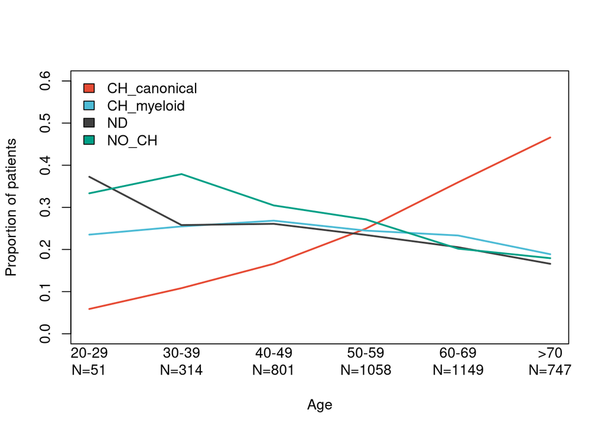

```r
cols = pal_npg()(8)
plot_cols = c(CH_canonical=cols[1], CH_myeloid=cols[2], ND="grey25",NO_CH=cols[3])

freqs = aggregate(pat_data$CHIP_STATUS, by=list(pat_data$age_bin), function(x){table(x) / length(x)})
freqs$counts = as.vector(table(pat_data$age_bin))

for(i in 1:ncol(freqs$x)){
  if(i == 1){
    plot(freqs$x[c(2:6,1),i], type='l', ylim=c(0,0.6), col=plot_cols[colnames(freqs$x)[i]], lwd=2, xaxt="n", xlab="Age", ylab="Proportion of patients")
    axis(1, 1:length(freqs$Group.1), paste0(freqs$Group.1[c(2:6,1)], "\nN=", freqs$counts[c(2:6,1)]), tick=F)
  }else{
    lines(freqs$x[c(2:6,1),i], col=plot_cols[colnames(freqs$x)[i]], lwd=2)
  }
}
legend("topleft", names(plot_cols), fill=plot_cols, bty='n')
```

```r
# p-value for difference in fraction of CH+ patients in oldest and youngest groups (fisher's exact test)
fisher.mat = matrix(c(nrow(subset(pat_data, age_bin %in% c("20-29","30-39") & CHIP_STATUS == "CH_canonical")),
                      nrow(subset(pat_data, age_bin %in% c("20-29","30-39") & CHIP_STATUS != "CH_canonical")),
                      nrow(subset(pat_data, age_bin %in% c(">70") & CHIP_STATUS == "CH_canonical")),
                      nrow(subset(pat_data, age_bin %in% c(">70") & CHIP_STATUS != "CH_canonical"))), nrow=2)
print (fisher.mat)
```

```
##      [,1] [,2]
## [1,]   37  348
## [2,]  328  399
```

```r
print(fisher.test(fisher.mat))
```

```
##
##  Fisher's Exact Test for Count Data
##
## data:  fisher.mat
## p-value < 2.2e-16
## alternative hypothesis: true odds ratio is not equal to 1
## 95 percent confidence interval:
##  0.08696868 0.18856032
## sample estimates:
## odds ratio
##   0.129552
```

```r
# repeat for PDF output
pdf("../output/Figure_2c.pdf", width=7, height=6, useDingbats = F)
for(i in 1:ncol(freqs$x)){
  if(i == 1){
    plot(freqs$x[c(2:6,1),i], type='l', ylim=c(0,0.6), col=plot_cols[colnames(freqs$x)[i]], lwd=2, xaxt="n", xlab="Age", ylab="Proportion of patients")
    axis(1, 1:length(freqs$Group.1), paste0(freqs$Group.1[c(2:6,1)], "\nN=", freqs$counts[c(2:6,1)]), tick=F)
  }else{
    lines(freqs$x[c(2:6,1),i], col=plot_cols[colnames(freqs$x)[i]], lwd=2)
  }
}
legend("topleft", names(plot_cols), fill=plot_cols, bty='n')
dev.off()
```

Figure S3 - Comparison of CH incidence in cancer and healthy controls (from other published works)

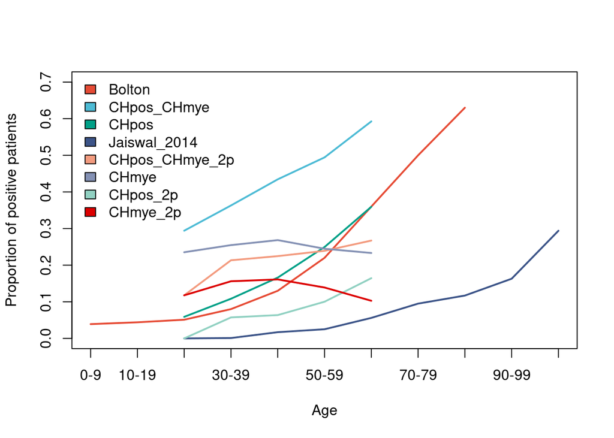

```r
pat_subset = subset(pat_data, !is.na(age_bin))

freqs_noAF = aggregate(pat_subset$CHIP_STATUS, by=list(pat_subset$age_bin), function(x){table(x) / length(x)})
freqs_noAF = data.frame(age.bin=freqs_noAF$Group.1, freqs_noAF$x)

pat_subset$CHIP_STATUS_2per = "NO_CH"
pat_subset$CHIP_STATUS_2per[!is.na(pat_subset$max.obs.myeloid.chip.af) & pat_subset$max.obs.myeloid.chip.af > 0.02] = "CH_myeloid"
pat_subset$CHIP_STATUS_2per[!is.na(pat_subset$max.obs.canon.chip.af) & pat_subset$max.obs.canon.chip.af > 0.02] = "CH_canonical"
freqs_AF = aggregate(pat_subset$CHIP_STATUS_2per, by=list(pat_subset$age_bin), function(x){table(x) / length(x)})
freqs_AF = data.frame(age.bin=freqs_AF$Group.1, freqs_AF$x)

# Bolton et al, 2020 (extended data table 1)
bolton_freq = data.frame(age.bin=c("0-9","10-19","20-29","30-39","40-49","50-59","60-69","70-79","80-89"),
                         CH=c(0.039, 0.044, 0.051, 0.08, 0.13, 0.22, 0.36, 0.50, 0.63))


# Jaiswal et al, 2014 (calculated from Figure 1)
jaiswal_freq = data.frame(age.bin=c("20-29","30-39","40-49","50-59","60-69","70-79","80-89","90-99","100-108"),
                          CH=c(0, 0.001, 0.017, 0.025, 0.056, 0.095, 0.117, 0.163, 0.294))

all_freqs = data.frame(age.bin=c("0-9","10-19","20-29","30-39","40-49","50-59","60-69","70-79","80-89","90-99","100-108"))
all_freqs$Bolton = bolton_freq[match(all_freqs$age.bin, bolton_freq$age.bin), "CH"]
all_freqs$CHpos_CHmye = rowSums(freqs_noAF[match(all_freqs$age.bin, freqs_noAF$age.bin), c("CH_canonical","CH_myeloid")])
all_freqs$CHpos = freqs_noAF[match(all_freqs$age.bin, freqs_noAF$age.bin), "CH_canonical"]
all_freqs$Jaiswal_2014 = jaiswal_freq[match(all_freqs$age.bin, jaiswal_freq$age.bin), "CH"]
all_freqs$CHpos_CHmye_2p = rowSums(freqs_AF[match(all_freqs$age.bin, freqs_AF$age.bin), c("CH_canonical","CH_myeloid")])
all_freqs$CHmye = freqs_noAF[match(all_freqs$age.bin, freqs_noAF$age.bin), "CH_myeloid"]
all_freqs$CHpos_2p = freqs_AF[match(all_freqs$age.bin, freqs_AF$age.bin), "CH_canonical"]
all_freqs$CHmye_2p = freqs_AF[match(all_freqs$age.bin, freqs_AF$age.bin), "CH_myeloid"]


for(i in 2:ncol(all_freqs)){
  if(i == 2){
    plot(1:nrow(all_freqs), all_freqs[,i], col=cols[i-1], type='l', lwd=2, xaxt="n", ylim=c(0,0.7),
         xlab="Age", ylab="Proportion of positive patients")
    axis(1, at=1:nrow(all_freqs), labels=all_freqs[,1], cex=0.8)
    legend("topleft", colnames(all_freqs)[2:ncol(all_freqs)], fill=cols, bty='n')
  }else{
    lines(1:nrow(all_freqs), all_freqs[,i], col=cols[i-1], type='l', lwd=2)
  }
}
```

```r
# repeat for PDF output
pdf("../output/Figure_S3.pdf", width=10, height=7, useDingbats = F)
for(i in 2:ncol(all_freqs)){
  if(i == 2){
    plot(1:nrow(all_freqs), all_freqs[,i], col=cols[i-1], type='l', lwd=2, xaxt="n", ylim=c(0,0.7),
         xlab="Age", ylab="Proportion of positive patients")
    axis(1, at=1:nrow(all_freqs), labels=all_freqs[,1], cex=0.8)
    legend("topleft", colnames(all_freqs)[2:ncol(all_freqs)], fill=cols, bty='n')
  }else{
    lines(1:nrow(all_freqs), all_freqs[,i], col=cols[i-1], type='l', lwd=2)
  }
}
dev.off()
```

Figure 3A - CH patients split by indication + age distribution panel

Note that the age distribution panel is slightly different from the published version as the patient ages needed to be grouped into 10-year bins for anonymity.

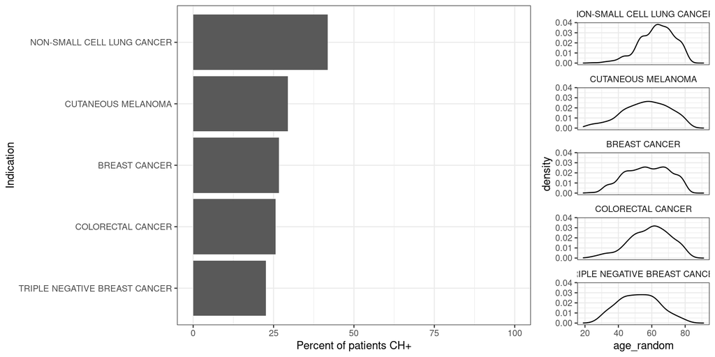

```r
pat_subset = subset(pat_data, !is.na(age_bin) & !is.na(INDIC))
pat_subset$age_random = as.numeric(gsub(">", "", gsub("-.*", "", pat_subset$age_bin))) + floor(runif(nrow(pat_subset),min=0,max=10)) + 1

pat_subset$CH = as.numeric(pat_subset$CHIP_STATUS == "CH_canonical")

# Use only indics with N > 100
pat_subset_indics = subset(pat_subset, unlist(INDIC) %in% c("NON-SMALL CELL LUNG CANCER", "TRIPLE NEGATIVE BREAST CANCER", "BREAST CANCER","CUTANEOUS MELANOMA","COLORECTAL CANCER"))


ch_indic_means = aggregate(pat_subset_indics$CH, by=list(pat_subset_indics$INDIC), mean)
ch_indic_means$x = ch_indic_means$x*100
barplot = ggplot(ch_indic_means, aes(x=reorder(Group.1, x), y=x)) + geom_bar(stat="identity") + ylim(0,100) +
  ylab("Percent of patients CH+") + xlab("Indication") + coord_flip() + theme_bw()


pat_subset_indics$INDIC = factor(pat_subset_indics$INDIC, levels=c("NON-SMALL CELL LUNG CANCER","CUTANEOUS MELANOMA","BREAST CANCER","COLORECTAL CANCER","TRIPLE NEGATIVE BREAST CANCER"))
density_plot = ggplot(pat_subset_indics, aes(x=age_random)) + geom_density() + xlim(19,91) +
    theme_bw() + theme(strip.background = element_blank()) + facet_wrap(facets=vars(pat_subset_indics$INDIC), ncol=1)


plot_grid(barplot, density_plot, nrow=1, rel_widths = c(3,1))
```

```r
pdf("../output/Figure_3a.pdf", width=15, height=7, useDingbats = F)
plot_grid(barplot, density_plot, nrow=1, rel_widths = c(3,1))
dev.off()
```

Figure 3B - CH odds ratio by indication, accounting for age

Note that this output is slightly different from the published version as the patient ages needed to be grouped into 10-year bins for anonymity.

```r
# Select patients with known age and indication, compare only CH-positive vs CH-negative (remove CH-myeloid)
pat_subset = subset(pat_data, !is.na(age_bin) & !is.na(INDIC))
pat_subset$age = as.numeric(gsub(">", "", gsub("-.*", "", pat_subset$age_bin)))
pat_subset$CH = NA
pat_subset$CH[pat_subset$CHIP_STATUS == "CH_canonical"] = 1
pat_subset$CH[pat_subset$CHIP_STATUS %in% c("ND","NO_CH")] = 0
pat_subset = subset(pat_subset, !is.na(CH))


# Use only indics with N > 100
pat_subset_indics = subset(pat_subset, unlist(INDIC) %in% c("NON-SMALL CELL LUNG CANCER", "TRIPLE NEGATIVE BREAST CANCER", "BREAST CANCER","CUTANEOUS MELANOMA","COLORECTAL CANCER"))

model = glm(pat_subset_indics$CH ~ unlist(pat_subset_indics$INDIC) + pat_subset_indics$age, family="binomial")
summary(model)
```

```
##
## Call:
## glm(formula = pat_subset_indics$CH ~ unlist(pat_subset_indics$INDIC) +
##     pat_subset_indics$age, family = "binomial")
##
## Deviance Residuals:
##     Min       1Q   Median       3Q      Max
## -1.5169  -0.9968  -0.6820   1.1005   2.1653
##
## Coefficients:
##                                                               Estimate
## (Intercept)                                                  -3.371407
## unlist(pat_subset_indics$INDIC)COLORECTAL CANCER              0.295102
## unlist(pat_subset_indics$INDIC)CUTANEOUS MELANOMA             0.112271
## unlist(pat_subset_indics$INDIC)NON-SMALL CELL LUNG CANCER     0.586417
## unlist(pat_subset_indics$INDIC)TRIPLE NEGATIVE BREAST CANCER  0.391111
## pat_subset_indics$age                                         0.050786
##                                                              Std. Error z value
## (Intercept)                                                    0.201418 -16.738
## unlist(pat_subset_indics$INDIC)COLORECTAL CANCER               0.180553   1.634
## unlist(pat_subset_indics$INDIC)CUTANEOUS MELANOMA              0.112461   0.998
## unlist(pat_subset_indics$INDIC)NON-SMALL CELL LUNG CANCER      0.119514   4.907
## unlist(pat_subset_indics$INDIC)TRIPLE NEGATIVE BREAST CANCER   0.202465   1.932
## pat_subset_indics$age                                          0.003553  14.296
##                                                              Pr(>|z|)
## (Intercept)                                                   < 2e-16 ***
## unlist(pat_subset_indics$INDIC)COLORECTAL CANCER               0.1022
## unlist(pat_subset_indics$INDIC)CUTANEOUS MELANOMA              0.3181
## unlist(pat_subset_indics$INDIC)NON-SMALL CELL LUNG CANCER    9.26e-07 ***
## unlist(pat_subset_indics$INDIC)TRIPLE NEGATIVE BREAST CANCER   0.0534 .
## pat_subset_indics$age                                         < 2e-16 ***
## ---
## Signif. codes:  0 '***' 0.001 '**' 0.01 '*' 0.05 '.' 0.1 ' ' 1
##
## (Dispersion parameter for binomial family taken to be 1)
##
##     Null deviance: 3847.2  on 2906  degrees of freedom
## Residual deviance: 3567.0  on 2901  degrees of freedom
## AIC: 3579
##
## Number of Fisher Scoring iterations: 4
```

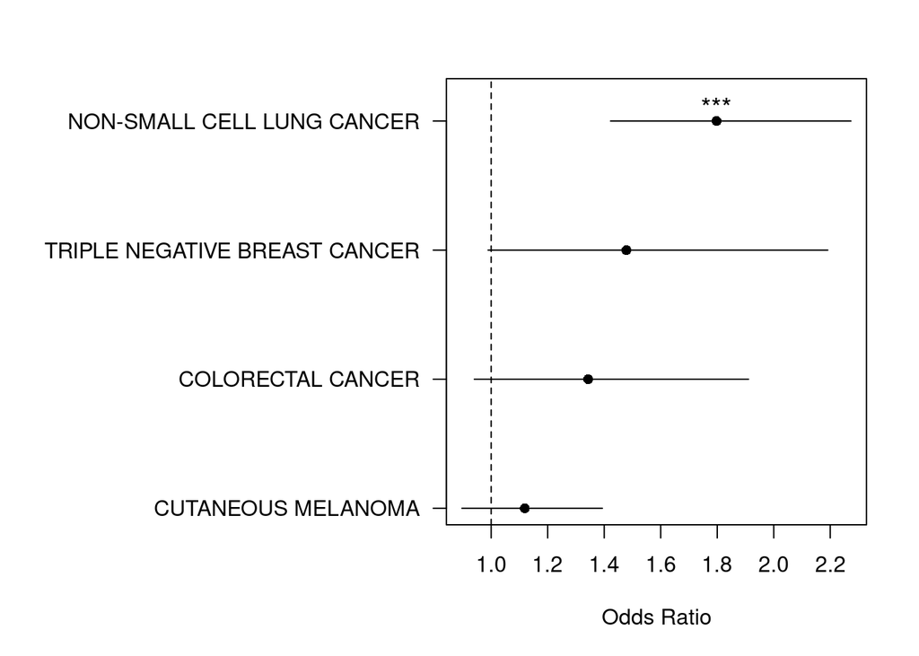

```r
plot_odds = function(model, num_indics, ...){
  num_lines = num_indics - 1

  # Get confidence interval values
  confint = as.data.frame(exp(confint(model)))
  confint$estimate = exp(coef(summary(model))[,"Estimate"])
  confint = confint[2:num_indics,]

  # Add pvalue to confint table
  confint$pvalue = coef(summary(model))[2:num_indics,"Pr(>|z|)"]
  confint = confint[order(confint$estimate),]


  # Plot logistic regression estimates with 95% confidence intervals
  par(mar=c(5,17,3,2))
  plot(confint$estimate, 1:num_lines, xlim=c(min(confint$`2.5 %`), max(confint$`97.5 %`)), yaxt='n', xlab="Odds Ratio", ylab="", pch=16, ylim=c(1,4.2), ...)
  axis(2, at=1:num_lines, labels=gsub(".*)", "", rownames(confint)), las=2)
  segments(confint$`2.5 %`, 1:num_lines, confint$`97.5 %`, 1:num_lines)
  abline(v=1, lty=2)
  # Add * for significance
  sig.points = c("***","**","*","")[.bincode(confint$pvalue, breaks=c(0,0.001,0.01,0.05,1))]
  text(confint$estimate, (1:num_lines)+0.15, sig.points, cex=1.2)

}

plot_odds(model, num_indics=5)
```

```r
pdf("../output/Figure_3b.pdf", width=7, height=4, useDingbats = F)
plot_odds(model, num_indics=5)
dev.off()
```

Figure S4a - CH odds ratio correcting for age and therapy

Note that this output is slightly different from the published version as the patient ages needed to be grouped into 10-year bins for anonymity.

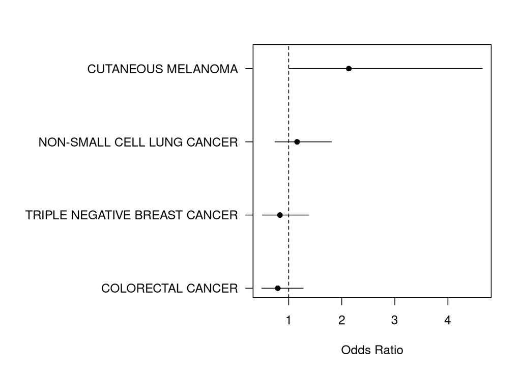

```r
# Select patients with known age, indication, and therapy history, compare only CH-positive vs CH-negative (remove CH-myeloid)
pat_subset = subset(pat_data, !is.na(age_bin) & !is.na(INDIC) & !is.na(chemo_last_line) & !is.na(chemo_any_line))
pat_subset$age = as.numeric(gsub(">", "", gsub("-.*", "", pat_subset$age_bin)))
pat_subset$CH = NA
pat_subset$CH[pat_subset$CHIP_STATUS == "CH_canonical"] = 1
pat_subset$CH[pat_subset$CHIP_STATUS %in% c("ND","NO_CH")] = 0
pat_subset = subset(pat_subset, !is.na(CH))

# Use only indics with N > 100
pat_subset_indics = subset(pat_subset, unlist(INDIC) %in% c("NON-SMALL CELL LUNG CANCER", "TRIPLE NEGATIVE BREAST CANCER", "BREAST CANCER","CUTANEOUS MELANOMA","COLORECTAL CANCER"))

# Panel 1: correcting only for age for patients with therapy information curated
model_panel1 = glm(pat_subset_indics$CH ~ unlist(pat_subset_indics$INDIC) + pat_subset_indics$age, family="binomial")
plot_odds(model_panel1, num_indics=5)
```

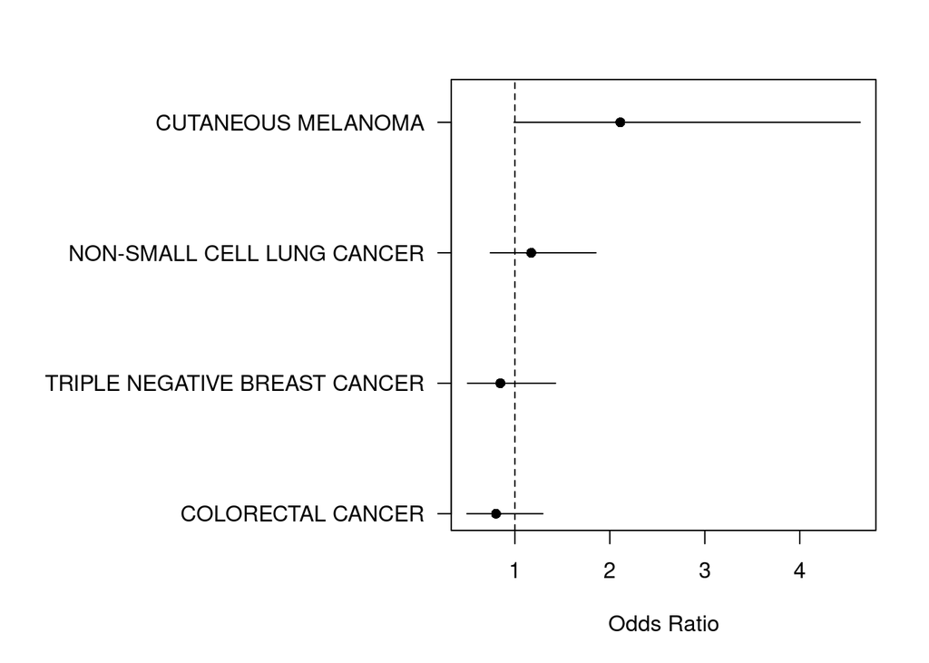

```r
# Panel 2: correcting for age and chemo as the most recent line of therapy
model_panel2 = glm(pat_subset_indics$CH ~ unlist(pat_subset_indics$INDIC) + pat_subset_indics$age + pat_subset_indics$chemo_last_line, family="binomial")
plot_odds(model_panel2, num_indics = 5)
```

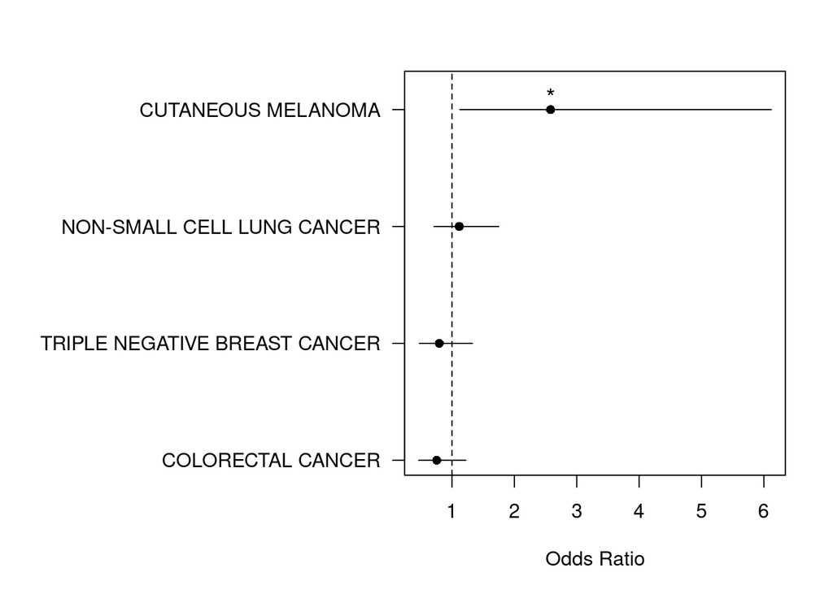

```r
# Panel 3: correcting for age and chemo as any line of therapy
model_panel3 = glm(pat_subset_indics$CH ~ unlist(pat_subset_indics$INDIC) + pat_subset_indics$age + pat_subset_indics$chemo_any_line, family="binomial")
plot_odds(model_panel3, num_indics = 5)
```

```r
pdf("../output/Figure_S4a.pdf", width=15, height=3, useDingbats = F)
par(mfrow=c(1,3))
plot_odds(model_panel1, num_indics=5)
plot_odds(model_panel2, num_indics=5)
plot_odds(model_panel3, num_indics=5)
dev.off()
```

Figure S4b - CH/CH-myeloid odds ratio by indication, accounting for age

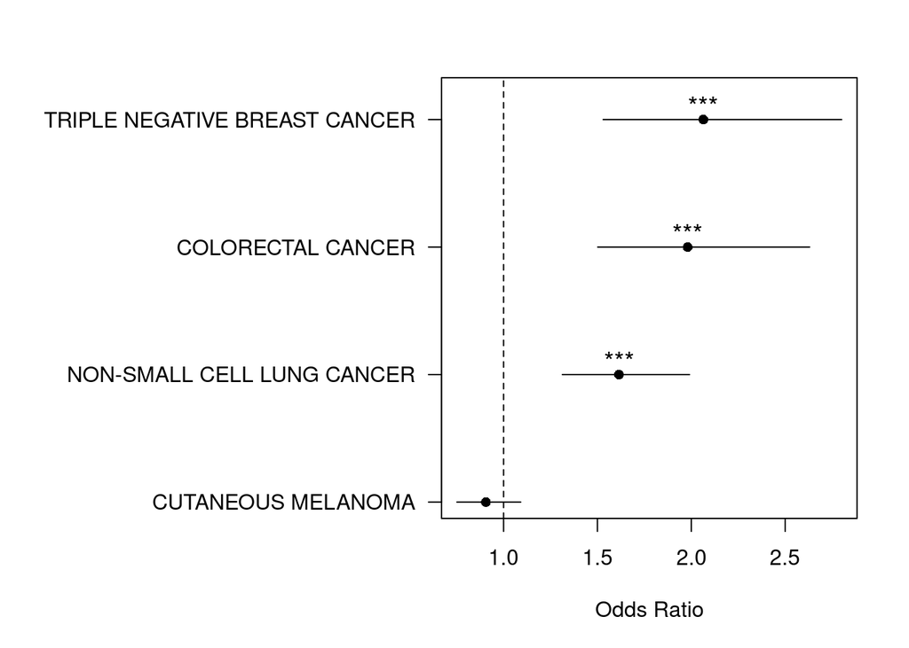

```r
# Select patients with known age and indication, compare CH-positive OR CH-myeloid vs CH-negative
pat_subset = subset(pat_data, !is.na(age_bin) & !is.na(INDIC))
pat_subset$age = as.numeric(gsub(">", "", gsub("-.*", "", pat_subset$age_bin)))
pat_subset$CH = NA
pat_subset$CH[pat_subset$CHIP_STATUS %in% c("CH_canonical", "CH_myeloid")] = 1
pat_subset$CH[pat_subset$CHIP_STATUS %in% c("ND","NO_CH")] = 0
pat_subset = subset(pat_subset, !is.na(CH))

# Use only indics with N > 100
pat_subset_indics = subset(pat_subset, unlist(INDIC) %in% c("NON-SMALL CELL LUNG CANCER", "TRIPLE NEGATIVE BREAST CANCER", "BREAST CANCER","CUTANEOUS MELANOMA","COLORECTAL CANCER"))

model = glm(pat_subset_indics$CH ~ unlist(pat_subset_indics$INDIC) + pat_subset_indics$age, family="binomial")

plot_odds(model, num_indics=5)
```

```r
pdf("../output/Figure_S4b.pdf", width=7, height=4, useDingbats = F)
plot_odds(model, num_indics=5)
dev.off()
```

Figure S5 - Odds ratios for specific genes

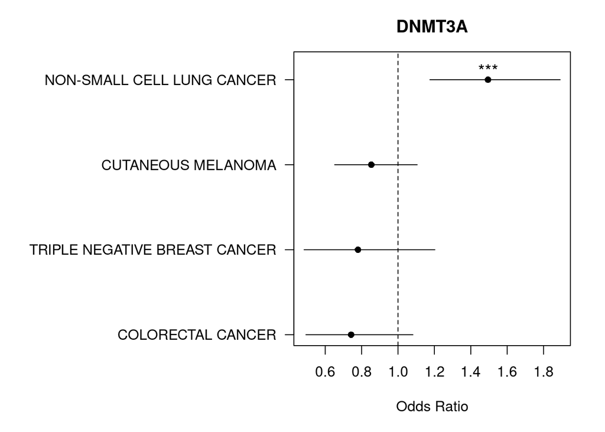

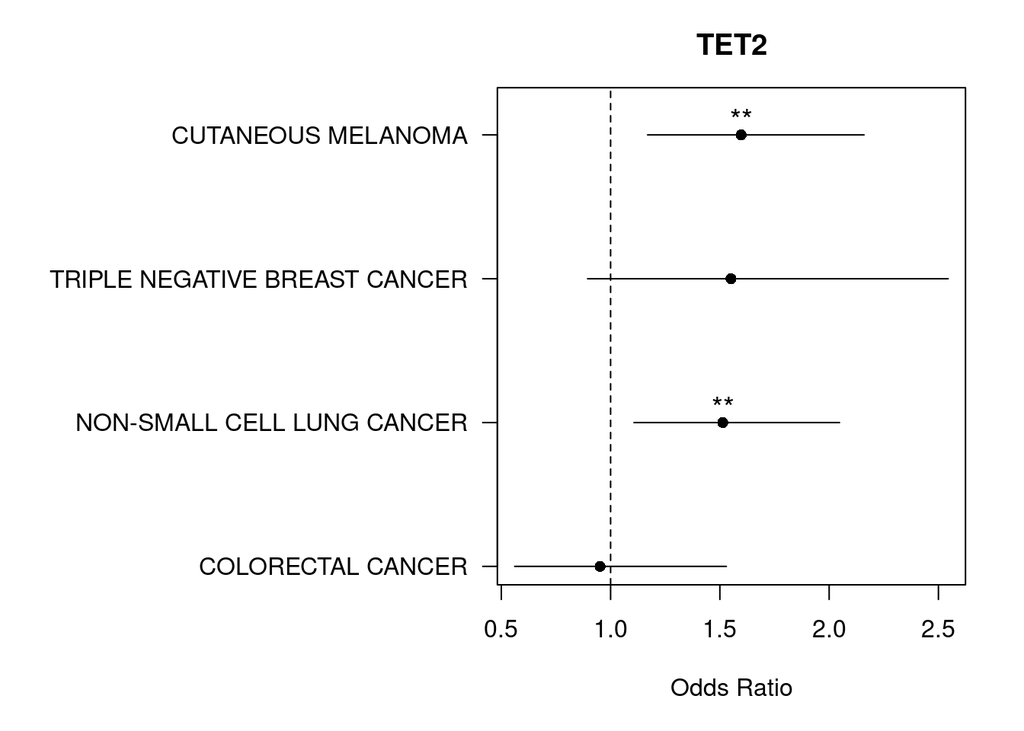

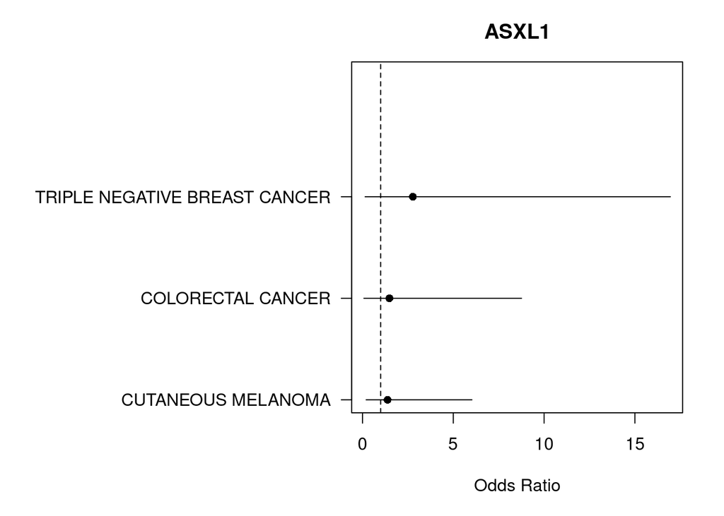

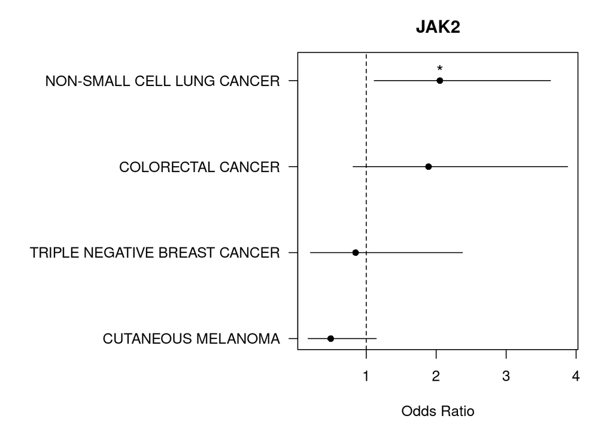

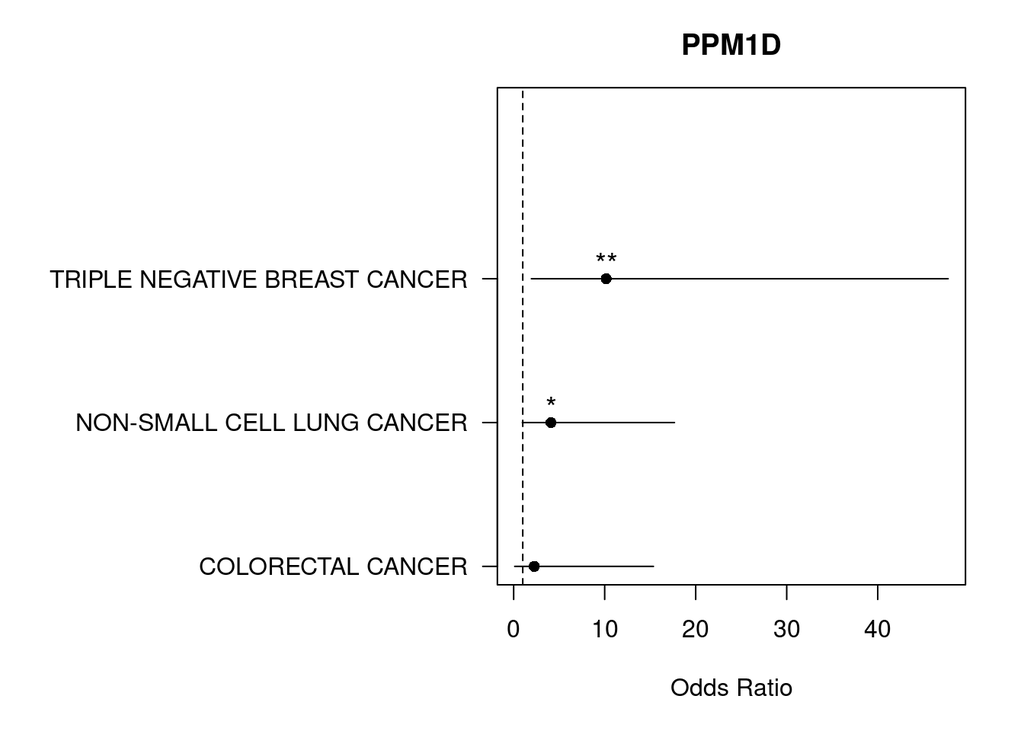

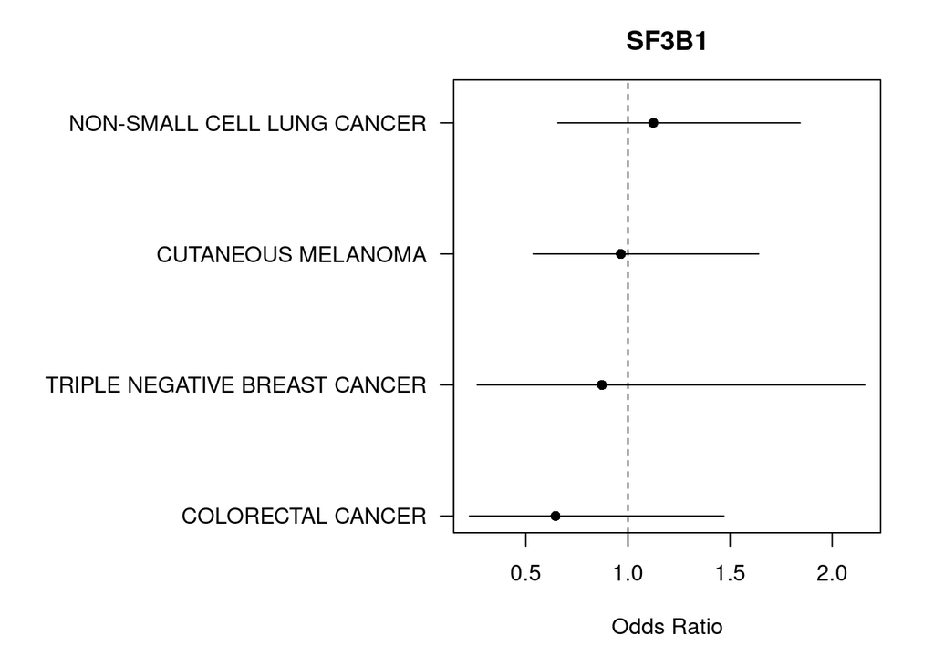

```r
genes_of_interest = c("DNMT3A","TET2","ASXL1","JAK2","PPM1D","SF3B1")#,"TP53")
indics = c("NON-SMALL CELL LUNG CANCER", "TRIPLE NEGATIVE BREAST CANCER", "BREAST CANCER","CUTANEOUS MELANOMA","COLORECTAL CANCER")

snv_calls = read.csv("/mnt/tmplabdata/ngdx/projects/methods_dev/CHIP/faircla1/manuscript_code_data/input/Anon_SNV_calls.csv", stringsAsFactors = F)
indel_calls = read.csv("/mnt/tmplabdata/ngdx/projects/methods_dev/CHIP/faircla1/manuscript_code_data/input/Anon_INDEL_calls.csv", stringsAsFactors = F)

for(gene in genes_of_interest){
  pos_pats = unique(c(subset(snv_calls, gene_name == gene)$anon_ID,
                      subset(indel_calls, gene_name == gene)$anon_ID))

  pat_subset = subset(pat_data, !is.na(age_bin) & !is.na(INDIC))
  pat_subset$age = as.numeric(gsub(">", "", gsub("-.*", "", pat_subset$age_bin)))
  pat_subset$CH = c(0,1)[as.numeric(pat_subset$anon_ID %in% pos_pats)+1]
  pat_subset_indics = subset(pat_subset, unlist(INDIC) %in% indics)

  # Remove indications with 0 mutations in gene of interest
  indics_keep = indics[indics %in% subset(pat_subset_indics, INDIC %in% indics & CH==1)$INDIC]
  pat_subset_indics = subset(pat_subset_indics, INDIC %in% indics_keep)

  model = glm(pat_subset_indics$CH ~ unlist(pat_subset_indics$INDIC) + pat_subset_indics$age, family="binomial")

  plot_odds(model, length(indics_keep), main=gene)
}
```

```r
# repeat for PDF output
pdf("../output/Figure_S5.pdf", width=20, height=7, useDingbats = F)
par(mfrow=c(2,4))
for(gene in genes_of_interest){
  pos_pats = unique(c(subset(snv_calls, gene_name == gene)$anon_ID,
                      subset(indel_calls, gene_name == gene)$anon_ID))

  pat_subset = subset(pat_data, !is.na(age_bin) & !is.na(INDIC))
  pat_subset$age = as.numeric(gsub(">", "", gsub("-.*", "", pat_subset$age_bin)))
  pat_subset$CH = c(0,1)[as.numeric(pat_subset$anon_ID %in% pos_pats)+1]
  pat_subset_indics = subset(pat_subset, unlist(INDIC) %in% indics)

  # Remove indications with 0 mutations in gene of interest
  indics_keep = indics[indics %in% subset(pat_subset_indics, INDIC %in% indics & CH==1)$INDIC]
  pat_subset_indics = subset(pat_subset_indics, INDIC %in% indics_keep)

  model = glm(pat_subset_indics$CH ~ unlist(pat_subset_indics$INDIC) + pat_subset_indics$age, family="binomial")

  plot_odds(model, length(indics_keep), main=gene)
}
dev.off()
```

Figure 3C - Barplots of CH gene frequency by indication

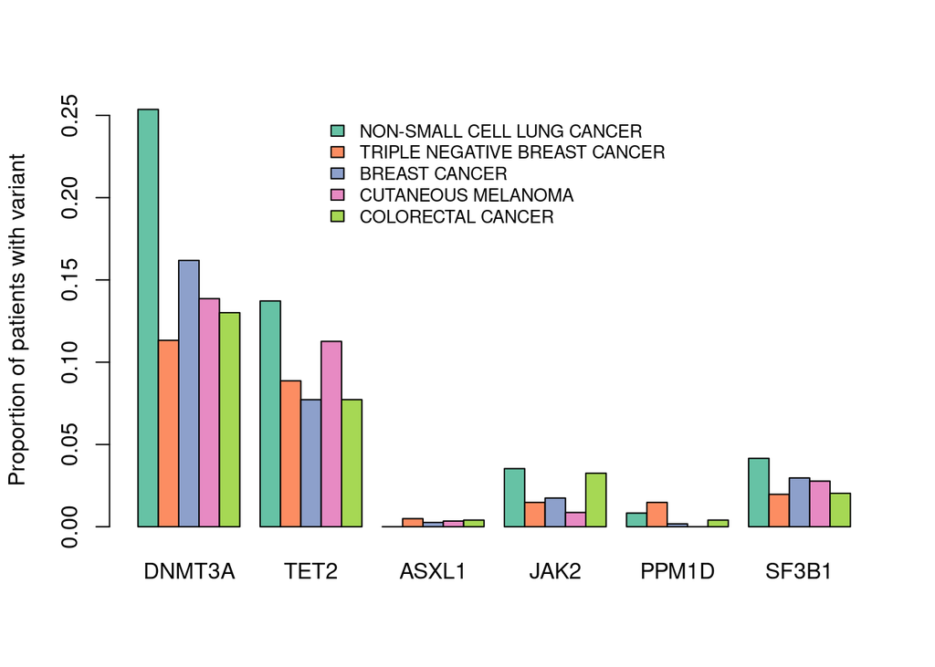

```r
# create matrix of counts, CH gene + by indication

ch_freqs = do.call(cbind, lapply(genes_of_interest, function(gene){
  pos_pats = unique(c(subset(snv_calls, gene_name == gene)$anon_ID,
                      subset(indel_calls, gene_name == gene)$anon_ID))
  pat_subset = subset(pat_data, !is.na(age_bin) & !is.na(INDIC))
  pat_subset$age = as.numeric(gsub(">", "", gsub("-.*", "", pat_subset$age_bin)))
  pat_subset$CH = c(0,1)[as.numeric(pat_subset$anon_ID %in% pos_pats)+1]
  pat_subset_indics = subset(pat_subset, unlist(INDIC) %in% indics)


  # proportion of patients with variant in gene
  counts = table(pat_subset_indics$INDIC)[indics]
  s = subset(pat_subset_indics, CH == 1)
  table(s$INDIC)[indics] / counts
}))

colnames(ch_freqs) = genes_of_interest

colors = brewer.pal(5, "Set2")
names(colors) = indics

barplot(ch_freqs, beside=T, col=colors, ylab="Proportion of patients with variant")
legend("top", indics, fill=colors, bty='n', cex=0.8)
```

```r
pdf("../output/Figure_3c.pdf", width=7, height=4, useDingbats = F)
barplot(ch_freqs, beside=T, col=colors, ylab="Proportion of patients with variant")
legend("top", indics, fill=colors, bty='n', cex=0.8)
dev.off()
```